# The cost, both human and financial, of storm events

I Carter (Coursera)

## Synopsis

In this project I carried out an analysis of the U.S. National Oceanic and Atmospheric Administration’s (NOAA) Storm Database. I recorded my exploratory analysis in `ExploratoryAnalysis.Rmd`. My goals were to discover which event types were most costly, firstly in terms of human life and health, and then in dollar terms.

## Data Processing

### Read in the dataset

```r
bz <- bzfile("repdata_data_StormData.csv.bz2", "r")
data <- read.csv(bz)
close(bz)
```

### Most Harmful `EVTYPE`s

*Across the United States, which types of events (as indicated in the `EVTYPE` variable) are most harmful with respect to population health?*

#### How many fatalities and injuries in total?

```r
total_deaths <- sum(data$FATALITIES)
total_deaths    ## 15145
```

```
## [1] 15145
```

```r
total_injuries <- sum(data$INJURIES)
total_injuries  ## 140528
```

```
## [1] 140528
```

#### Which are the top ten fatal event types?

```r
fatal <- tapply(data$FATALITIES, data$EVTYPE, sum)
fatal_percentage <- fatal/total_deaths * 100
fatal[which.max(fatal)]         ## which is the most fatal event type?
```

```
## TORNADO
##    5633
```

```r
fatal_indices <- order(fatal, decreasing=TRUE)
fatal[fatal_indices[1:10]]
```

```
##        TORNADO EXCESSIVE HEAT    FLASH FLOOD           HEAT      LIGHTNING
##           5633           1903            978            937            816
##      TSTM WIND          FLOOD    RIP CURRENT      HIGH WIND      AVALANCHE
##            504            470            368            248            224
```

```r
fatal_percentage[fatal_indices[1:10]]
```

```
##        TORNADO EXCESSIVE HEAT    FLASH FLOOD           HEAT      LIGHTNING
##      37.193793      12.565203       6.457577       6.186860       5.387917
##      TSTM WIND          FLOOD    RIP CURRENT      HIGH WIND      AVALANCHE
##       3.327831       3.103334       2.429845       1.637504       1.479036
```

#### Which are the top ten injurious event types?

```r
injurious <- tapply(data$INJURIES, data$EVTYPE, sum)
injurious_percentage <- injurious/total_injuries * 100
injurious[which.max(injurious)]    ## which is the most injurious event type?
```

```
## TORNADO
##   91346
```

```r
injurious_indices <- order(injurious, decreasing=TRUE)
injurious[injurious_indices[1:10]]
```

```
##           TORNADO         TSTM WIND             FLOOD    EXCESSIVE HEAT
##             91346              6957              6789              6525
##         LIGHTNING              HEAT         ICE STORM       FLASH FLOOD
##              5230              2100              1975              1777
## THUNDERSTORM WIND              HAIL
##              1488              1361
```

```r
injurious_percentage[injurious_indices[1:10]]
```

```
##           TORNADO         TSTM WIND             FLOOD    EXCESSIVE HEAT
##        65.0019925         4.9506148         4.8310657         4.6432028
##         LIGHTNING              HEAT         ICE STORM       FLASH FLOOD
##         3.7216782         1.4943641         1.4054139         1.2645167
## THUNDERSTORM WIND              HAIL
##         1.0588637         0.9684903
```

## The Most Dangerous Event Types

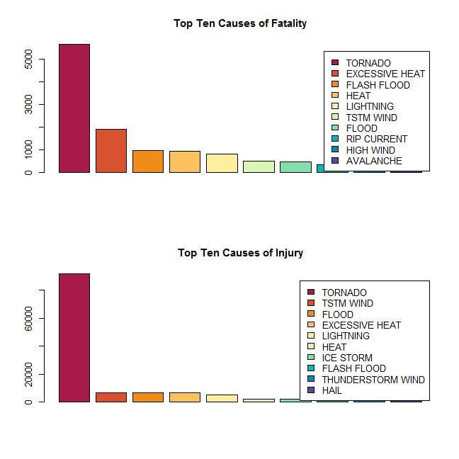

```r
par(mfrow=c(2, 1), cex=0.8)
barplot(fatal[fatal_indices[1:10]], axisnames=FALSE,
    col = hcl.colors(10, palette="Spectral"), legend=TRUE)
title("Top Ten Causes of Fatality")
barplot(injurious[injurious_indices[1:10]], axisnames=FALSE,
    col = hcl.colors(10, palette="Spectral"), legend=TRUE)
title("Top Ten Causes of Injury")
```

To improve our analysis we might take into account that some `EVTYPE`s seem to be synonyms of each other (e.g. “THUNDERSTORM WINDS”, “THUNDERSTORM WIND”, “THUNDERSTORM WINDSS”).

### Costliness

*Across the United States, which types of events have the greatest economic consequences?*

The relevant columns seem to be `PROPDMG`, `PROPDMGEXP`, `CROPDMG`, and `CROPDMGEXP`.

```r
levels(data$PROPDMGEXP)         ## ""  "-" "?" "+" "0" "1" "2" "3" "4" "5" "6" "7" "8" "B" "h" "H" "K" "m" "M"
```

```
##  [1] ""  "-" "?" "+" "0" "1" "2" "3" "4" "5" "6" "7" "8" "B" "h" "H" "K" "m" "M"
```

```r
levels(data$CROPDMGEXP)
```

```
## [1] ""  "?" "0" "2" "B" "k" "K" "m" "M"
```

```r
summary(data$CROPDMGEXP)        ## ""  "?" "0" "2" "B" "k" "K" "m" "M"
```

```
##             ?      0      2      B      k      K      m      M
## 618413      7     19      1      9     21 281832      1   1994
```

```r
summary(data$PROPDMGEXP)
```

```
##             -      ?      +      0      1      2      3      4      5      6
## 465934      1      8      5    216     25     13      4      4     28      4
##      7      8      B      h      H      K      m      M
##      5      1     40      1      6 424665      7  11330
```

“h” or “H” seems to stand for hundreds; “k” or “K” for thousands; “m” or “M” for millions; and “B” for billions.

*Please see Exploratory Analysis file for an examination of `PROPDMG` & `PROPDMGEXP`.* My conclusion is that the numeric values of `PROPDMGEXP`, and indeed of `PROPDMG`, are not very reliable. However we will use the data as-is, bearing in mind that some of it may be wrong.

First here is a helper function to convert the factor levels to integer multipliers:

```r
getMultiplier <- function(exp) {
    if(length(grep("[0-8]", exp)) > 0) {
        exp <- 10^as.numeric(exp)
    }
    else {
        exp <- toupper(exp)
        exp <- switch(exp,
            B = 1000000000,
            M = 1000000,
            K = 1000,
            H = 100,
            1)
    }
    exp
}
```

Now we make two new columns to record property and crop damage figures. We first figure out the multiplier, e.g. 100, 1000, etc. and then we multiply it by the figure given in `PROPDMG` and `CROPDMG`.

I reckon sapplying on just the levels is more efficient, rather than converting the factor to a character vector, and then running sapply to get the multipliers.

```r
data$PROPDMGTOT <- data$PROPDMGEXP
temp <- levels(data$PROPDMGEXP)
levels(data$PROPDMGTOT) <- sapply(temp, getMultiplier)
data$PROPDMGTOT <- levels(data$PROPDMGTOT)[data$PROPDMGTOT]
data$PROPDMGTOT <- as.numeric(data$PROPDMGTOT) * data$PROPDMG

data$CROPDMGTOT <- data$CROPDMGEXP
temp <- levels(data$CROPDMGEXP)
levels(data$CROPDMGTOT) <- sapply(temp, getMultiplier)
data$CROPDMGTOT <- levels(data$CROPDMGTOT)[data$CROPDMGTOT]
data$CROPDMGTOT <- as.numeric(data$CROPDMGTOT) * data$CROPDMG
```

*Now we figure out the worst `EVTYPE`s, similar to the code we used for injuries and fatalities.*

### The Most Costly Event Types

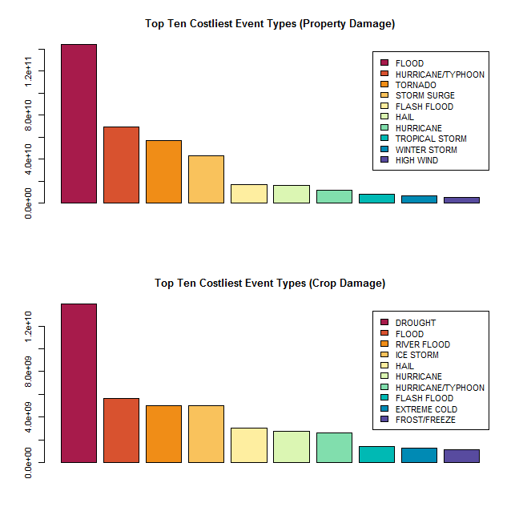

```r
property <- tapply(data$PROPDMGTOT, data$EVTYPE, sum)
property_indices <- order(property, decreasing=TRUE)
crop <- tapply(data$CROPDMGTOT, data$EVTYPE, sum)
crop_indices <- order(crop, decreasing=TRUE)

par(mfrow=c(2, 1), cex=0.7)
barplot(property[property_indices[1:10]], axisnames=FALSE,
    col = hcl.colors(10, palette="Spectral"), legend=TRUE)
title("Top Ten Costliest Event Types (Property Damage)")
barplot(crop[crop_indices[1:10]], axisnames=FALSE,
    col = hcl.colors(10, palette="Spectral"), legend=TRUE)
title("Top Ten Costliest Event Types (Crop Damage)")
```

#### How much damage in total?

```r
total_propdmg <- sum(data$PROPDMGTOT)
prettyNum(total_propdmg, big.mark=",")  ## 428 billion
```

```
## [1] "428,224,868,768"
```

```r
total_cropdmg <- sum(data$CROPDMGTOT)
prettyNum(total_cropdmg, big.mark=",")  ## 49 billion
```

```
## [1] "49,104,192,181"
```

## Results

The questions that need answers are:

### Most Harmful `EVTYPE`s

Across the United States, which types of events (as indicated in the `EVTYPE` variable) are most harmful with respect to population health?

*Answer: Tornados, by far.*

However this likely varies considerably by region, something that was not addressed in my analysis.

### Economic Consequences

Across the United States, which types of events have the greatest economic consequences?

*Answer: Floods overall, although Drought is a more serious problem where crops are concerned.*

Crop damage is about an order of magnitude less costly than property damage.

This document was processed on: 2020-07-04.